# **Python Tutorial - MIS346**

### Types of Inheritance:

**Single Inheritance:** A child class inherits from a single parent class.

**Multiple Inheritance:** A child class inherits from more than one parent class.

**Multilevel Inheritance**: A child class inherits from a parent class, which in turn inherits from another class.

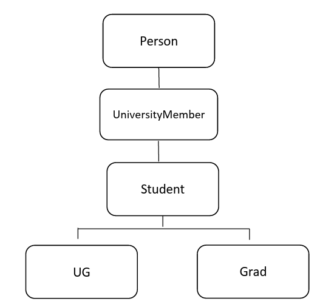

```python
# Single Inheritance
class Vehicle:
    def __init__(self, make, model):
        self.make = make
        self.model = model

    def display_info(self):
        print(f"Vehicle Make: {self.make}, Model: {self.model}")

class Car(Vehicle):  # Single Inheritance
    def drive(self):
        print(f"The {self.make} {self.model} is driving.")
```

```python
# Multilevel Inheritance
class ElectricCar(Car):  # Multilevel Inheritance
    def charge(self):
        print(f"The {self.make} {self.model} is charging.")
```

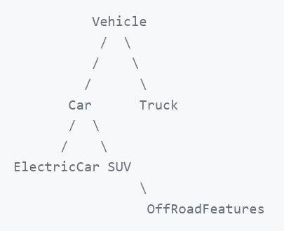

```python
# Multiple Inheritance
class OffRoadFeatures:
    def off_road(self):
        print("This vehicle has off-road capabilities!")

class SUV(Car, OffRoadFeatures):  # Multiple Inheritance
    def drive(self):
        print(f"The {self.make} {self.model} is driving off-road.")
```

```python
# Example Usage
sedan = Car("Toyota", "Camry")
sedan.display_info()
sedan.drive()

togg = ElectricCar("TOGG", "T10X")
togg.display_info()
togg.drive()
togg.charge()

suv = SUV("Opel", "Crossland")
suv.display_info()
suv.drive()
suv.off_road()
```

```
Vehicle Make: Toyota, Model: Camry
The Toyota Camry is driving.
Vehicle Make: TOGG, Model: T10X
The TOGG T10X is driving.
The TOGG T10X is charging.
Vehicle Make: Opel, Model: Crossland
The Opel Crossland is driving off-road.
This vehicle has off-road capabilities!
```

### isinstance() Function

The `isinstance(object, type)` function checks **if an object is an instance of a specified type (or a subclass**).

It returns **True** if the object is an instance of the given class or a tuple of classes; otherwise, it returns False.

```python
isinstance(togg, ElectricCar)
```

```
True
```

```python
isinstance(togg, Car)
```

```
True
```

```python
isinstance(togg, object)
```

```
True
```

```python
isinstance(togg, SUV)
```

```
False
```

### Information Hiding and Inheritance

Information hiding is a principle that encourages encapsulating the internal state of an object and restricting direct access to its attributes.

In Python, this is typically done using a naming convention that involves prefixing the attribute with double underscores `(__)`.

This name mangling makes the attribute less accessible for subclasses, which can lead to AttributeError if a subclass tries to access a hidden attribute directly.

**Inheritance and Accessing Hidden Attributes** **When a subclass inherits from a superclass, it can access public and protected attributes** but may struggle with private attributes due to information hiding.

Instead of accessing hidden attributes directly, subclasses are encouraged to use **getter and setter methods** that allow for controlled access and modification of the attributes.

```python
class Parent:
    def __init__(self):
        self.__hidden_attribute = "I'm hidden!"

    def get_hidden_attribute(self):
        return self.__hidden_attribute

    def set_hidden_attribute(self, value):
        self.__hidden_attribute = value

class Child(Parent):
    def access_hidden(self):
        try:
            # Attempting to access the hidden attribute directly
            print(self.__hidden_attribute)  # This will raise AttributeError
        except AttributeError:
            print("AttributeError: Cannot access hidden attribute directly.")

        # Correct way: Accessing via getter
        hidden_value = self.get_hidden_attribute()
        print(f"Accessed hidden attribute via getter: {hidden_value}")

# Usage
child_instance = Child()
child_instance.access_hidden()
```

```
AttributeError: Cannot access hidden attribute directly.
Accessed hidden attribute via getter: I'm hidden!
```

**Explanation:**

**Parent Class:** Contains a hidden attribute `(__hidden_attribute)` and provides public methods (`get_hidden_attribute` and `set_hidden_attribut`e) to access and modify this attribute.

**Child Class:** Attempts to access the `__hidden_attribute` directly, which results in AttributeError. Instead, it correctly accesses the hidden attribute through the `get_hidden_attribute()` method.

## Polymorphism

**Polymorphism** allows **methods to have the same name but behave differently** based on the object's context.

This can be achieved through **method overriding (run-time polymorphism)** and **method overloading (compile-time polymorphism)**.

### **Run-Time Polymorphism** (overriding)

**Run-time polymorphism occurs when a subclass overrides a method** of its parent class.

The method that gets executed is determined at runtime based on the actual object type. This allows for dynamic method resolution.

```python
# Parent Class
class Animal:
    def make_sound(self):
        print("Animal Sound")

# Subclass: Dog
class Dog(Animal):
    #overriding
    def make_sound(self):
        print("Woof!")

# Subclass: Cat
class Cat(Animal):
    #overriding
    def make_sound(self):
        print("Meow!")

# Subclass: Cow
class Cow(Animal):
    #overriding
    def make_sound(self):
        print("Moo!")

#Subclass: Elephant
class Elephant(Animal):
    pass

animal_base=Animal()
animal_base.make_sound()

cat=Cat()
cat.make_sound()

dog=Dog()
dog.make_sound()

cow=Cow()
cow.make_sound()

elephant=Elephant()
elephant.make_sound()
```

```
Animal Sound
Meow!
Woof!
Moo!
Animal Sound
```

**Explanation of Code:**

In this example, the Animal class defines a method make_sound() that is meant to be overridden by its subclasses.

The subclasses **Dog, Cat, and Cow each provide their specific implementation** of the make_sound() method. But Elephant use it's parrent class make_sound() method.

**the correct make_sound() method is called based on the actual type of the object**, demonstrating **run-time polymorphism**.

### Compile-Time Polymorphism (overloading)

**Compile-time polymorphism** is typically achieved through method overloading, where **multiple methods with the same name can exist but accept different parameters.**

However, **Python does not support method overloading in the traditional sense**. Instead, **we can mimic this behavior using default arguments**.

```python
class Calculator:
    def multiply(self, a, b=1, c=1):
        return a * b * c  # Supports different ways to call multiply()

# Using the Calculator class
calc = Calculator()

# Demonstrating compile-time polymorphism
result1 = calc.multiply(5, 3)       # Two arguments: 5 * 3
result2 = calc.multiply(4, 2, 2)    # Three arguments: 4 * 2 * 2
result3 = calc.multiply(7)           # One argument: 7 * 1 * 1

print(f"Result of 5 * 3: {result1}")  # Outputs: 15
print(f"Result of 4 * 2 * 2: {result2}")  # Outputs: 16
print(f"Result of 7: {result3}")  # Outputs: 7
```

```
Result of 5 * 3: 15
Result of 4 * 2 * 2: 16
Result of 7: 7
```

**Explanation:**

In the Calculator class, the `multiply()`method uses default arguments to allow for flexibility in how it is called.

Depending on the number of arguments provided, the same method name (multiply) can perform different operations:

- With two arguments, it multiplies a and b.
- With three arguments, it multiplies a, b, and c.
- With one argument, it returns a multiplied by the defaults of b and c (which are both 1).

This mimics c**ompile-time polymorphism** by allowing the method to behave differently based on the number of parameters passed.

```python
class Shape:
    def area(self):
        return "Undefined"  # Default implementation for area

class Rectangle(Shape):
    def __init__(self, length, width):
        self.length = length  # Initialize length
        self.width = width    # Initialize width

    def area(self):
        return self.length * self.width  # Area calculation for rectangle

class Circle(Shape):
    def __init__(self, radius):
        self.radius = radius  # Initialize radius

    def area(self):
        return 3.14 * self.radius ** 2  # Area calculation for circle

# Create a list of different shapes
shapes = [Rectangle(2, 3), Circle(5)]

# Polymorphism in action: calling area on different shape instances
for shape in shapes:
    print(f"Area: {shape.area()}")
```

```
Area: 6
Area: 78.5
```

**Base Class: Shape**

The Shape class defines a method called `area()` that returns "Undefined". This serves as a placeholder for shapes that do not have a defined area.

**Subclass: Rectangle**

The Rectangle class inherits from Shape and initializes with specific attributes: *length* and *width*.

The `area()` method is overridden to return the area of the rectangle, calculated as length * width

**Subclass: Circle**

The Circle class also inherits from Shape and initializes with a radius attribute.

**Polymorphism in Action:**

- A list shapes contains instances of Rectangle and Circle.
- When iterating through the list and calling the `area()` method on each shape, the appropriate method is executed based on the object's type, demonstrating run-time polymorphism.

**Summary of Polymorphism:**

- **Run-time polymorphism** allows for dynamic method resolution based on the object type at runtime, enabling subclasses to define specific behaviors.
- **Compile-time polymorphism** in Python is mimicked through the use of default arguments, allowing a single method to handle varying numbers of parameters and perform different operations based on how it is called.

These concepts enhance the flexibility and maintainability of code by allowing for more generic and reusable designs.

## Abstraction

**Abstraction** is a programming concept that hides internal implementation details and exposes only the essential features of an object.

This focuses the developer's effort on **"what to do"** rather than **"how to do it,"** promoting cleaner and more understandable code.

**Types of Abstraction**

### Partial Abstraction:

An abstract class that contains **both abstract methods (methods without implementation) and concrete methods** (methods with implementation).

### Full Abstraction:

An abstract class or interface where **all methods are abstract and must be implemented by derived classes.**

```python
from abc import ABC, abstractmethod

# Abstract Class
class Animal(ABC):
    def __init__(self, name):
        self.name = name  # Concrete attribute

    @abstractmethod
    def make_sound(self):  # Abstract Method
        pass

    def display_name(self):  # Concrete Method
        print(f"Animal's Name: {self.name}")
```

```python
# Subclass: Dog (Partial Abstraction)
class Dog(Animal):
    def make_sound(self):  #it must be implemented
        print("Woof!")

# Subclass: Cat (Partial Abstraction)
class Cat(Animal):
    def make_sound(self): #it must be implemented
        print("Meow!")
```

```python
# Example Usage
animals = [Dog("Buddy"), Cat("Whiskers")]
for animal in animals:
    animal.display_name()  # Calls the concrete method from the abstract class
    animal.make_sound()    # Calls the implemented abstract method
```

**Abstract Class - Animal:**

This class inherits from `ABC (Abstract Base Class)` and serves as a blueprint for various animal types.

It has an initializer method `(__init__)`that defines a concrete attribute (name).

**The abstract method make_sound()** is defined but not implemented, thus requiring subclasses to provide their specific sound.

**Concrete Method - display_name():**

This is a concrete method that prints the name of the animal. This method can be reused by all subclasses without requiring implementation.

**Subclasses - Dog and Cat:**

**Both Dog and Cat classes extend the Animal class**, implement the `make_sound()` method specific to their type, fulfilling the requirement of the abstract class. They automatically inherit the `display_name()` method from the Animal class.

**Example Usage:**

A list of animals is created, consisting of **Dog and Cat instances**. In the loop, each animal's name and sound are displayed, showcasing the inheritance of concrete methods and the implementation of abstract methods.

**Summary**

**Partial Abstraction:**

The Animal class demonstrates partial abstraction, containing both abstract (`make_sound()`) and concrete (`display_name()`) methods.

**Importance of Abstraction:**

This allows the design to ensure consistency in derived classes by enforcing the implementation of the `make_sound()` method while providing a common functionality through `display_name()`.

**Abstraction not only simplifies code management but also ensures that derived classes adhere to a specific interface, making the codebase more organized and maintainable.**

## Python Iterators

An **iterator** is an object that allows you to **traverse through a collection** (like *lists, tuples, or strings*) without needing to know the underlying structure. It follows the iterator protocol, which consists of two main methods:

`__iter__()`: This method **returns the iterator object itself** and is required for an object to be considered an iterable.

`__next__()`: This method **returns the next value** from the iterator. When there are no more items to return, it should raise a **StopIteration exception**.

### Iterable vs. Iterator

**Iterable:**

An object that can return an iterator (e.g., lists, tuples, dictionaries, sets, strings). You can obtain an iterator from an iterable using the `iter()` function.

**Iterator:**

An object that implements the iterator protocol (`__iter__() and __next__()` methods). It is used to iterate over the values in an iterable.

```python
# my_list is an iterable object
my_list = [1, 2, 3]

for item in my_list:
    print(item)
```

```
1
2
3
```

**Basic Iteration with Built-in Iterables**

```python
#Example with a tuple, it is an iterable object
my_tuple = ("apple", "banana", "cherry")
my_iterator = iter(my_tuple)

print(next(my_iterator))  # Output: apple
print(next(my_iterator))  # Output: banana
print(next(my_iterator))  # Output: cherry

#we use __iter__() and __next__() methods
```

```
apple
banana
cherry
```

**Iterating Through a String**

```python
#string objects are iterable
my_string = "banana"
my_iterator = iter(my_string)

print(next(my_iterator))  # Output: b
print(next(my_iterator))  # Output: a
print(next(my_iterator))  # Output: n
print(next(my_iterator))  # Output: a
print(next(my_iterator))  # Output: n
print(next(my_iterator))  # Output: a
```

```
b
a
n
a
n
a
```

You can use a **for loop to iterate through an iterable, which internally uses the `__next__()` method**:

```python
# Looping through a tuple
my_tuple = ("apple", "banana", "cherry")
for fruit in my_tuple:
    print(fruit)

# Looping through a string
my_string = "banana"
for char in my_string:
    print(char)
```

```
apple
banana
cherry
b
a
n
a
n
a
```

### Creating a Custom Iterator

To create your own iterator, **you need to define a class** that implements (overrides) the `__iter__()` and `__next__()` methods.

```python
class MyNumbers:
    def __iter__(self):
        self.current = 1  # Initialize the starting number
        return self

    def __next__(self):
        if self.current <= 20:  # Limit the iteration to 20
            number = self.current
            self.current += 1
            return number
        else:
            raise StopIteration  # Stop the iteration

# Using the custom iterator
my_numbers = MyNumbers()
my_iterator = iter(my_numbers)

for num in my_iterator:
    print(num)  # Prints numbers from 1 to 20
```

```
1
2
3
4
5
6
7
8
9
10
11
12
13
14
15
16
17
18
19
20
```

**Conclusion**

- **Iterators provide a powerful way to traverse collections** without exposing their internal structure.
- Using the**`iter()` function allows you to create an iterator** from any iterable.
- Custom iterators can be created by implementing the `__iter__()` and `__next__()` methods, giving you control over the iteration process.

# Python Datetime

The **datetime** module in Python allows you to **manipulate dates and times** in both simple and complex ways. It provides several classes, including:

- **datetime:** Combines both date and time.
- **date:** Represents only the date (year, month, day).
- **time:** Represents only the time (hour, minute, second, microsecond).
- **timedelta:** Represents the difference between two dates or times.

### Getting the Current Date and Time

You can easily get the current date and time using the `now()` method of the `datetime` class.

```python
import datetime

# Get the current date and time
current_datetime = datetime.datetime.now()
print("Current Date and Time:", current_datetime)
```

```
Current Date and Time: 2025-03-13 12:27:18.403796
```

### Accessing Date Attributes

You can access various attributes of a datetime object, such as the **year, month, day, hour, minute, second, and microsecond**.

```python
import datetime

# Get the current date and time
current_datetime = datetime.datetime.now()

# Accessing year and weekday name
print("Year:", current_datetime.year)
print("Weekday:", current_datetime.strftime("%A"))  # Full weekday name
```

```
Year: 2025
Weekday: Thursday
```

### Creating Date Objects

You can create a specific date using the `datetime()` constructor. This constructor requires the year, month, and day as parameters.

```python
import datetime

# Create a date object for May 17, 2020
specific_date = datetime.datetime(2020, 5, 17)
print("Specific Date:", specific_date)
```

```
Specific Date: 2020-05-17 00:00:00
```

### Formatting Dates with **strftime()**

The `strftime()` method allows you to format datetime objects into readable strings. You can specify the format using various format codes.

```python
import datetime

# Create a date object for June 1, 2018
date_example = datetime.datetime(2018, 6, 1)

# Format the date to display the month name
formatted_month = date_example.strftime("%B")
print("Month Name:", formatted_month)
```

```
Month Name: June
```

### Common Format Codes

Here are some **common format codes** you can use with strftime():

%Y: Year with century (e.g., 2025)

%y: Year without century (e.g., 25)

%m: Month as a zero-padded decimal (01 to 12)

%B: Full month name (e.g., January)

%b: Abbreviated month name (e.g., Jan)

%d: Day of the month as zero-padded decimal (01 to 31)

%A: Full weekday name (e.g., Monday)

%H: Hour (00 to 23)

%M: Minute (00 to 59)

```python
import datetime

# Create a date object for March 13, 2025
date_time_example = datetime.datetime(2025, 3, 13, 15, 30, 45)

# Format the date and time
formatted_date_time = date_time_example.strftime("%A, %B %d, %Y at %I:%M %p")
print("Formatted Date and Time:", formatted_date_time)
```

```
Formatted Date and Time: Thursday, March 13, 2025 at 03:30 PM
```

The datetime module in Python is a powerful tool for handling dates and times.

It allows you to create date objects, format them, and perform various operations.

Whether you need to calculate differences between dates, format dates for display, or simply retrieve the current date and time, the datetime module has you covered.

# Python Exception Handling

In Python, exceptions are events that disrupt the normal flow of a program and arise during execution. Exception handling allows you to write robust and user-friendly programs by gracefully dealing with errors.

**Basic Structure of Exception Handling**

**try Block:** Code that may cause an exception is placed here.

**except Block:** This block catches and handles the exception.

**else Block:** Code here runs only if no exceptions were raised in the try block.

**finally Block:** This block, if present, always executes, regardless of whether an exception was raised or not.

```python
try:
    print(10 / 0)  # This will raise a ZeroDivisionError
except ZeroDivisionError:
    print("You can't divide by zero!")
```

```
You can't divide by zero!
```

### Multiple Except Blocks

You can define different actions for different types of exceptions.

```python
try:
    value = int(input("Enter a number: "))
    result = 10 / value
except ValueError:
    print("That's not a valid number!")
except ZeroDivisionError:
    print("You can't divide by zero!")
else:
    print(f"Result: {result}")
finally:
    print("Execution finished.")
```

```
Enter a number: a
That's not a valid number!
Execution finished.
```

### Using Finally Block

The `finally` block is useful for cleaning up resources, such as closing files or database connections.

```python
try:
    file = open("example.txt", "r")
    content = file.read()
    print(content)
except FileNotFoundError:
    print("File not found!")
finally:
    if 'file' in locals():
        file.close()
        print("File closed.")
```

```
File not found!
```

### Raising Exceptions

You can also raise exceptions using the raise keyword to enforce certain conditions in your code.

```python
def check_age(age):
    if age < 0:
        raise ValueError("Age cannot be negative")
    elif age < 18:
        print("You are a minor.")
    else:
        print("You are an adult.")

    try:
        check_age(-1)
    except ValueError as e:
        print(f"Error: {e}")

age=int(input("enter age: "))

check_age(age)
```

```
enter age: -3
```

[output not shown]

### Raising TypeError

You can define specific exceptions based on the conditions you want to enforce in your functions.

```python
def add_numbers(x, y):
    if not isinstance(x, int) or not isinstance(y, int):
        raise TypeError("Both arguments must be integers.")
    return x + y

try:
    result = add_numbers(10, "5")
except TypeError as e:
    print(f"Error: {e}")
```

```
Error: Both arguments must be integers.
```

**Summary**

- `try:` Encapsulates code that may throw an exception.
- `except:` Handles specific exceptions.
- `else:` Executes code when no exceptions occur.
- `finally:` Executes code regardless of exceptions (commonly used for cleanup).
- `raise:` Allows the programmer to trigger an exception manually.

By using exception handling effectively, you can create code that is more robust and easier to maintain.

**This way, your programs can handle unexpected situations** gracefully without crashing.

# Python Math Module

## Python Built-in Math Functions

Python includes several **built-in functions** for performing basic **mathematical operations** directly.

## min() and max():

These functions are used to find the minimum and maximum values from a set of input values or from an iterable like a list or tuple.

```python
# Finding minimum and maximum values
x = min(5, 10, 25)
y = max(5, 10, 25)

print("Minimum value:", x)  # Output: 5
print("Maximum value:", y)  # Output: 25
```

```
Minimum value: 5
Maximum value: 25
```

## abs()

This function returns the absolute value of a number, which removes any negative sign.

```python
# Getting the absolute value
x = abs(-7.25)

print("Absolute value:", x)  # Output: 7.25
```

```
Absolute value: 7.25
```

**pow()**

This function calculates the power of a number. The first argument is the base, and the second is the exponent.

```python
# Power calculation
x = pow(4, 3)

print("4 to the power of 3:", x)  # Output: 64
```

```
4 to the power of 3: 64
```

## The Math Module

The **math module** offers a wider range of **mathematical functions and constants**. To use the functions within this module, **you must first import it**.

```python
import math
```

```python
x = math.sqrt(64)
print("Square root of 64:", x)  # Output: 8.0
```

```
Square root of 64: 8.0
```

`math.ceil()`: Rounds a number up to the nearest integer.

`math.floor()`: Rounds a number down to the nearest integer.

```python
import math

x = math.ceil(1.4)  # Rounds up
y = math.floor(1.4) # Rounds down

print("Ceiling of 1.4:", x)  # Output: 2
print("Floor of 1.4:", y)    # Output: 1
```

```
Ceiling of 1.4: 2
Floor of 1.4: 1
```

### Constants

- `math.pi`: Represents the value of π (pi), approximately 3.14159.
- `math.e`: Represents the base of the natural logarithm, approximately 2.71828.

```python
import math

# Using the value of pi
x = math.pi
print("Value of Pi:", x)  # Output: 3.141592653589793

# Using the value of e
e_value = math.e
print("Value of e:", e_value)  # Output: 2.718281828459045
```

```
Value of Pi: 3.141592653589793
Value of e: 2.718281828459045
```

### Additional Functions in the Math Module

The math module contains many other useful functions:

**Trigonometric Functions:**

`math.sin(), math.cos(), math.tan()`

**Logarithmic Functions:**

`math.log(), math.log10()`

**Factorial Function:**

`math.factorial()`: Returns the factorial of a non-negative integer.

```python
import math

fact_5 = math.factorial(5)
print("Factorial of 5:", fact_5)  # Output: 120
```

```
Factorial of 5: 120
```

**Summary:**

The built-in math functions and the math module in Python provide a robust set of tools for performing a wide variety of mathematical operations.

From finding minimum and maximum values to performing complex calculations, these features make Python an excellent choice for tasks involving mathematics and numerical analysis.

# Python Working with JSON

**JSON** (JavaScript Object Notation) is a **lightweight data interchange format that is easy for humans to read and write.**

It is also easy for machines to parse and generate.

JSON represents data in a structured way, using **key-value pairs** similar to dictionaries in Python.

**Example JSON Format:**

```python
# Example JSON string representing a book
book_json = '{"title": "Animal Farm", "author": "George Orwell", "year": 1945, "genre": "Political Satire"}'
```

## Parsing JSON to Python

First, import the `json` module. Then use `loads` method. It **converts to python dictionary**.

```python
import json

# Example JSON string representing a book
book_json = '{"title": "Animal Farm", "author": "George Orwell", "year": 1945, "genre": "Political Satire"}'

# Parse JSON string to Python dictionary
book_dict = json.loads(book_json)

# Accessing data from the dictionary
print("Title:", book_dict["title"])      # Output: Animal Farm
print("Author:", book_dict["author"])    # Output: George Orwell
print("Year:", book_dict["year"])        # Output: 1945
print("Genre:", book_dict["genre"])      # Output: Political Satire
```

```
Title: Animal Farm
Author: George Orwell
Year: 1945
Genre: Political Satire
```

## Converting Python to JSON

Let’s convert a Python **dictionary representing a movie to a JSON string**. we use `dumps` method to conver json.

```python
import json

# Example Python dictionary for a movie
movie_dict = {
    "title": "Inception",
    "director": "Christopher Nolan",
    "year": 2010,
    "cast": ["Leonardo DiCaprio", "Joseph Gordon-Levitt", "Elliot Page"]
}

# Convert Python dictionary to JSON string
movie_json = json.dumps(movie_dict)

# Output the JSON string
print(movie_json)
```

```
{"title": "Inception", "director": "Christopher Nolan", "year": 2010, "cast": ["Leonardo DiCaprio", "Joseph Gordon-Levitt", "Elliot Page"]}
```

## Handling Various Python Objects

We will demonstrate **converting several different types of objects into JSON** using new variables.

```python
import json

# Different Python objects
print(json.dumps({"brand": "Apple", "model": "iPhone 13", "price": 799}))
print(json.dumps(["Python", "JavaScript", "C++"]))
print(json.dumps(("rock", "jazz", "classical")))
print(json.dumps("welcome"))
print(json.dumps(99))                    # int
print(json.dumps(19.99))                # float
print(json.dumps(None))                 # None -> null
print(json.dumps({"available": True, "in_stock": False}))  # Nested dictionary
```

```
{"brand": "Apple", "model": "iPhone 13", "price": 799}
["Python", "JavaScript", "C++"]
["rock", "jazz", "classical"]
"welcome"
99
19.99
null
{"available": true, "in_stock": false}
```

## Complex Data Structure

```python
import json

smartphone = {
    "brand": "Samsung",
    "model": "Galaxy S21",
    "specifications": {
        "display": "6.2 inches",
        "processor": "Exynos 2100",
        "ram": "8 GB",
        "storage_options": ["128 GB", "256 GB"]
    },
    "available_colors": ["Phantom Gray", "Phantom White", "Phantom Violet"],
    "is_5G_enabled": True
}

# Convert to JSON
smartphone_json = json.dumps(smartphone)
print(smartphone_json)
```

```
{"brand": "Samsung", "model": "Galaxy S21", "specifications": {"display": "6.2 inches", "processor": "Exynos 2100", "ram": "8 GB", "storage_options": ["128 GB", "256 GB"]}, "available_colors": ["Phantom Gray", "Phantom White", "Phantom Violet"], "is_5G_enabled": true}
```

## Formatting the JSON Output

Let’s demonstrate how to format the output of the smartphone data with indentation and sorted keys.

```python
formatted_smartphone_json = json.dumps(smartphone, indent=4, sort_keys=True)
print(formatted_smartphone_json)
```

```
{
    "available_colors": [
        "Phantom Gray",
        "Phantom White",
        "Phantom Violet"
    ],
    "brand": "Samsung",
    "is_5G_enabled": true,
    "model": "Galaxy S21",
    "specifications": {
        "display": "6.2 inches",
        "processor": "Exynos 2100",
        "ram": "8 GB",
        "storage_options": [
            "128 GB",
            "256 GB"
        ]
    }
}
```

# Python Regular Expressions (RegEx)

A **RegEx**, or **Regular Expression**, is a **sequence of characters that forms a search pattern**.

To start using regular expressions in Python, you first need to import the `re` module.

```python
import re
```

A simple example to check if a **string starts with "The" and ends with "Spain"**.

```python
txt = "The rain in Spain"
x = re.search("^The.*Spain$", txt)

if x:
    print("Match found!")
else:
    print("No match.")
```

```
Match found!
```